# R作业2

2233361郭旭

2022-11-25

## 1 Using the iri dateset

### 1.1 Get a subset with STATE_CODE 6 and SHRP_ID starting with 050

筛选出iri数据集中**STATE_CODE**值为**6**且**SHRP_ID**开头为**050**的数据。

```r
library(tidyverse)
library(data.table)

iri <- fread("data-assignment\\LTPP\\iri.csv")
iri_6_050 <-
  iri |>
  dplyr::filter(STATE_CODE == 6 & stringr::str_detect(SHRP_ID,"^050"))
iri_6_050
```

```
##      STATE_CODE SHRP_ID CONSTRUCTION_NO           VISIT_DATE    IRI
##   1:          6    0501               1 1/25/90, 12:00:00 AM 3.7206
##   2:          6    0501               1 2/11/92, 12:00:00 AM 3.8896
##   3:          6    0501               1 2/16/91, 12:00:00 AM 3.6434
##   4:          6    0501               2 2/11/98, 12:00:00 AM 1.4376
##   5:          6    0501               2  2/2/93, 12:00:00 AM 1.1230
##  ---
## 131:          6    0509               3 2/17/01, 12:00:00 AM 1.3848
## 132:          6    0509               3 3/12/05, 12:00:00 AM 3.5420
## 133:          6    0509               3 3/25/04, 12:00:00 AM 2.9830
## 134:          6    0509               3  3/5/03, 12:00:00 AM 2.1488
## 135:          6    0509               4 3/21/07, 12:00:00 AM 5.2614
```

### 1.2 Get the summary statistics of each section: min, max, and mean

对iri数据集中数据进行分组，并统计各组数量，然后分别计算各组**IRI**的**最小值、最大值和平均值**。

```r
iri_m <- iri |>
  group_by( STATE_CODE, SHRP_ID ) |>
  summarise(
    observation = n(),
    iri_max = max(IRI),
    iri_min = min(IRI),
    iri_mean = mean(IRI),.groups = "drop"
  )
iri_m
```

```
## # A tibble: 2,576 × 6
##    STATE_CODE SHRP_ID observation iri_max iri_min iri_mean
##         <int> <chr>         <int>   <dbl>   <dbl>    <dbl>
##  1          1 0101             17   0.810   0.657    0.716
##  2          1 0102             18   3.10    0.897    1.34
##  3          1 0103              9   0.834   0.760    0.803
##  4          1 0104             10   0.684   0.594    0.644
##  5          1 0105              9   0.694   0.614    0.648
##  6          1 0106             10   0.764   0.582    0.688
##  7          1 0107              6   0.963   0.628    0.747
##  8          1 0108             11   0.875   0.731    0.766
##  9          1 0109              9   0.775   0.679    0.736
## 10          1 0110             10   0.764   0.672    0.705
## # … with 2,566 more rows
```

### 1.3 Sort the summarized data by mean IRI in descending order (report results for one section only)

首先根据**IRI平均值**，对数据进行**降序**排序，然后筛选出一组数据进行展示。

```r
iri_m_order <-
  iri_m |>
  arrange(-iri_mean) |>
  dplyr::filter(STATE_CODE == 6 & str_detect(SHRP_ID,"050"))
iri_m_order
```

```
## # A tibble: 9 × 6
##   STATE_CODE SHRP_ID observation iri_max iri_min iri_mean
##        <int> <chr>         <int>   <dbl>   <dbl>    <dbl>
## 1          6 0502             15    4.11   0.953     2.21
## 2          6 0509             15    5.26   1.01      2.19
## 3          6 0501             15    3.89   1.12      2.14
## 4          6 0505             15    3.30   0.717     1.61
## 5          6 0506             15    3.12   0.808     1.39
## 6          6 0507             15    2.35   0.834     1.35
## 7          6 0503             15    1.78   1.04      1.28
## 8          6 0504             15    1.89   1.02      1.26
## 9          6 0508             15    2.06   0.747     1.20
```

### 1.4 Generate a scatter plot for the averaged IRI against the time for a selected section, and then give your interpretation of the plot

首先筛选出要处理的数据，然后根据对数据进行分组，并求IRI平均值，最后对所选部分的**IRI平均值**和**时间**的关系生成**散点图**。

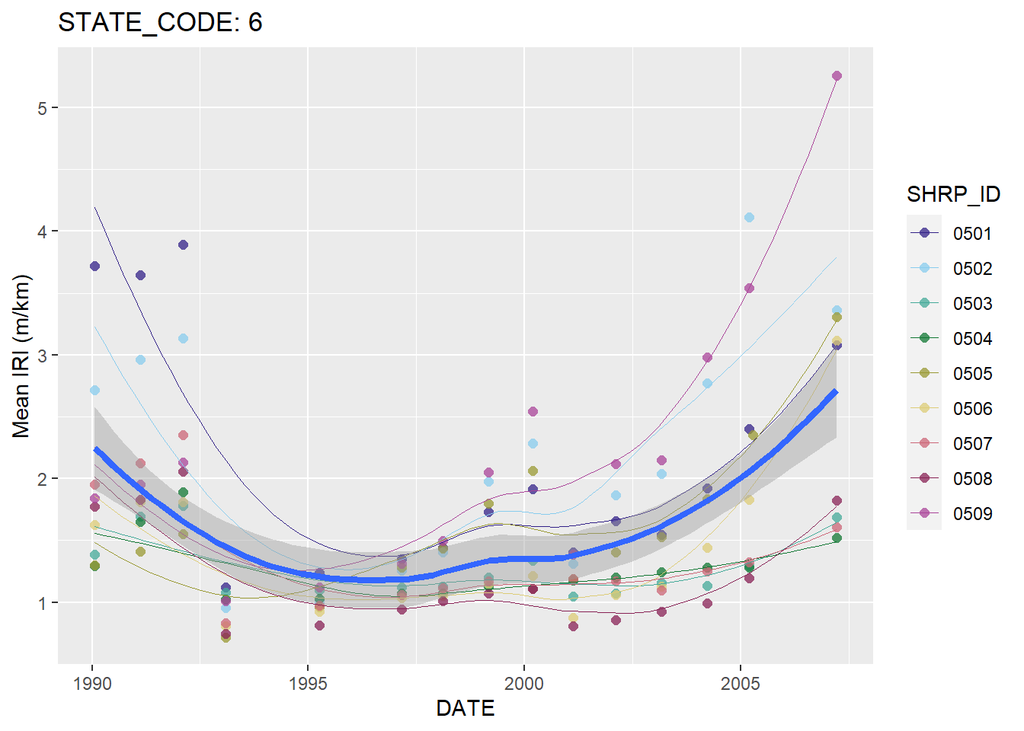

```r
library(ggthemes)

iri_date_IRI <-
  fread("data-assignment\\LTPP\\iri.csv") |>
  dplyr::filter(STATE_CODE == 6 & str_detect(SHRP_ID,"050")) |>
  group_by(STATE_CODE, SHRP_ID, VISIT_DATE) |>
  summarise(iri_mean = mean(IRI),.groups = "drop") |>
  separate(VISIT_DATE, into=c("VISIT_DATE", "time"), sep="\\,") |>
  mutate(VISIT_DATE = parse_date(VISIT_DATE, "%m/%d/%y")) |>
  mutate_if(is.numeric, ~round(.x, 3))

p1 <-
  iri_date_IRI |>
  ggplot(aes(x=VISIT_DATE, y=iri_mean)) +
  geom_point(aes(color=SHRP_ID), shape=16, size=2, stroke=1/2, alpha=3/4) +
  geom_smooth(aes(color=SHRP_ID), method="loess", se=FALSE, linewidth=1/3) +
  geom_smooth(method="loess", se=TRUE, linewidth=3/2) +
  scale_color_ptol() +
  labs(x="DATE", y="Mean IRI (m/km)", title="STATE_CODE: 6")
p1
```

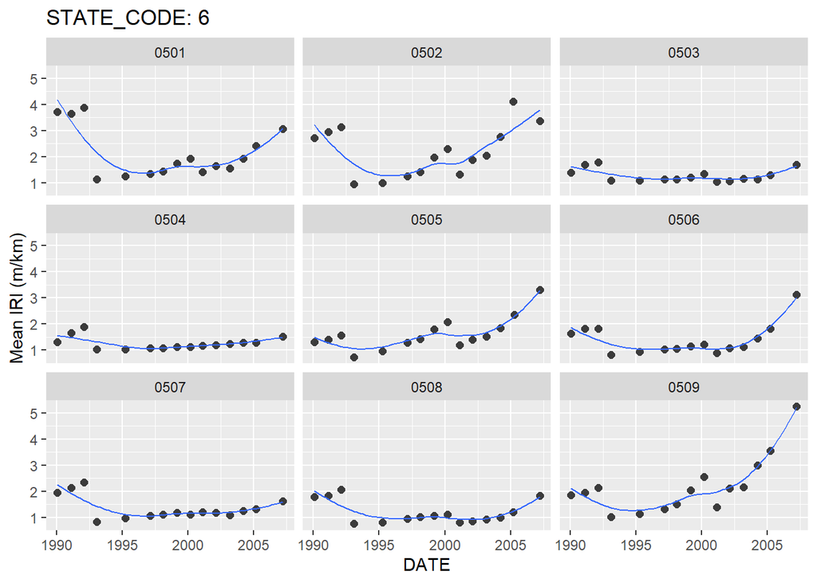

```r
p2 <-
  iri_date_IRI |>
  ggplot(aes(x=VISIT_DATE, y=iri_mean)) +
  geom_point(shape=16, size=2, stroke=1/2, alpha=3/4) +
  geom_smooth(method="loess", se=FALSE, linewidth=1/2) +
  scale_color_brewer() +
  facet_wrap(~SHRP_ID, ncol=3) +
  labs(x="DATE", y="Mean IRI (m/km)", title="STATE_CODE: 6")
p2
```

**数据分析：**经过查询相关资料，IRI为国际平整度指数。**整体分析：**根据数据分析所得的散点图，筛选出的相关路段IRI指数整体呈现出先降后升的趋势。早期路面平整度下降，原因可能是新建公路缺乏路面养护或路面养护方法效果不佳；中期路面国际平整度指数基本保持不变，说明养护作业效果较好；后期路面国际平整度指数升高，原因可能是对路面进行了翻修，或者采用了新的更有效的养护技术。**分组分析：**其中，3、4、7、8号路段国际平整度指数均保持在一定范围内，说明养护作业效果良好，并且未采取新的措施或方法；5、6号路段国际平整度指数前中期保持在一定范围内，后期升高值较大，可能采取了新措施或方法；1、2、9号路段，国际平整度指数咸下降到一定水平，后升高，可能道路新建一段时间后才开始养护作业，并在后期采取了新措施或新养护方法。

## 2 Using the CRSS datasets in 2017

### 2.1 Get the intersection of the datasets accident and person

对**ACCIDENT**和**PERSON**数据集进行了**inner_join**操作。

```r
library(data.table)

datasets_intersection <-
  list("data-assignment/CRSS/ACCIDENT.csv",
       "data-assignment/CRSS/PERSON.csv") |>
  map(fread) |>
  reduce(inner_join) |>
  distinct()
```

### 2.2 Tabulate the total number of observations in each injury severity (INJ_SEV)

统计不同每种**损伤严重程度**的**数量**。

```r
inj_sev_obs <-
  fread("data-assignment/CRSS/PERSON.csv") |>
  group_by(INJ_SEV) |>
  summarise(INI_SEV_NUM = n(),.groups = "drop")
inj_sev_obs
```

```
## # A tibble: 8 × 2
##   INJ_SEV INI_SEV_NUM
##     <int>       <int>
## 1       0       91720
## 2       1       21248
## 3       2       12303
## 4       3        7230
## 5       4        1096
## 6       5         510
## 7       6           4
## 8       9        4802
```

### 2.3 Merge the accident dataset with the vehicle dataset, and report the dimension of your results and number of missing values in one variable of the right dataset

合并**accident**和**vehicle**数据集(**left_join**)，并计算合并后数据集的**维度**和右侧数据集其中一个变量的**缺失值数量**。

```r
acc_veh_left <-
  list("data-assignment/CRSS/ACCIDENT.csv",
       "data-assignment/CRSS/VEHICLE.csv") |>
  map(fread) |>
  reduce(left_join) |>
  distinct()
dim(acc_veh_left)
```

```
## [1] 97625   123
```

```r
sum(is.na(acc_veh_left$VEH_NO))
```

```
## [1] 0
```

## 3 Push your homework to a git repository

在本地建立git仓库，并push到git远程仓库中,github界面截图及链接如下。  
[GitHub远程仓库仓库链接](https://github.com/GuoXu1718/R_homework2.git)

[figure not shown]